# Lab 7

- Show All Code
- Hide All Code
- View Source

Author

Chloe Feehan

## 1. Data

```r
library(tidyverse)
library(here)

fish <- read_csv(here("Labs", "Lab 7", "BlackfootFish.csv"))
```

## 2. Part One: Summaries and Plots

### 2.1 Summarizing Missing Data

What variable(s) have missing values present? What variable(s) have missing values present?

```r
fish |>
  summarize(
    across(.cols = c(trip:species),
           .fns = ~sum(is.na(.x)))
  )
```

```
# A tibble: 1 × 7
   trip  mark length weight  year section species
  <int> <int>  <int>  <int> <int>   <int>   <int>
1     0     0      0   1796     0       0       0
```

The variable that has missing values present is weight. There are 1796 missing values.

### 2.2 Visualizing Missing Data

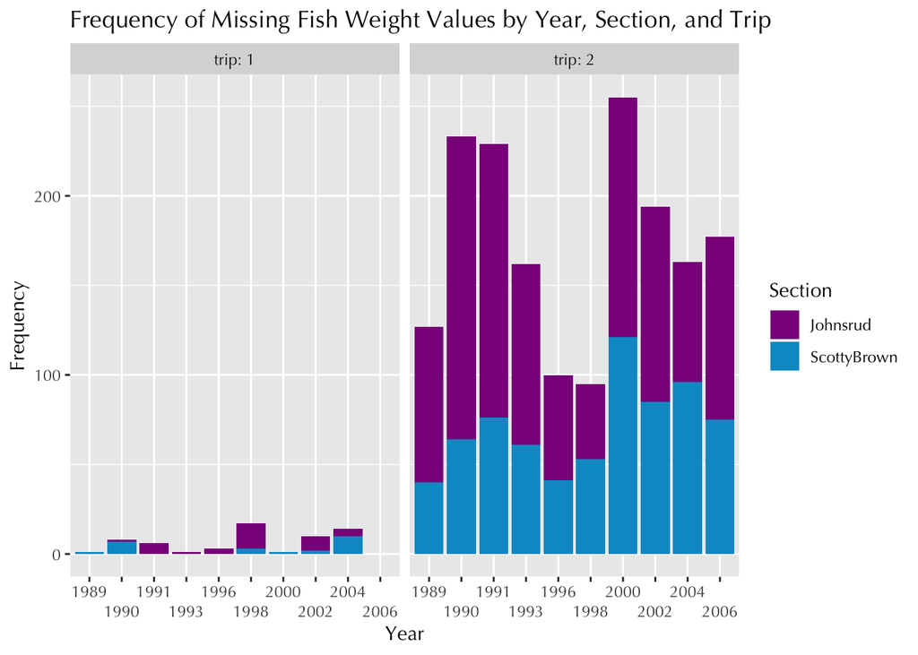

```r
fish |>
  filter(
    is.na(weight)
  ) |>

ggplot(mapping = aes(x = as.factor(year), fill = section)) +
  facet_grid(~trip, labeller = label_both) +
  geom_bar() +
  scale_fill_manual(values = c("darkmagenta", "deepskyblue3")) +
  labs(x = "Year", y = "Frequency",
       title = "Frequency of Missing Fish Weight Values by Year, Section, and Trip",
       fill = "Section") +
  scale_x_discrete(guide = guide_axis(n.dodge = 2)) +
  theme(text = element_text(family = "Optima"))
```

```r
#https://r-graphics.org/recipe-facet-label-text
```

```r
rescale_01 <- function(var) {
  stopifnot(is.numeric(var),
            length(var) > 1)

  rng = range(var, na.rm = TRUE)

  num <- var - rng[1]
  denom <- rng[2] - rng[1]

  num / denom
}

#rescale_01(fish$length)
#rescale_01(fish$weight)
```

### 3.3 First, test your function on the simple vector below. Add code that verifies the maximum of your rescaled vector is 1 and the minimum is 0!

```r
x <- c(1:85, NA)

x1 <- rescale_01(x)
range(x1, na.rm = TRUE)
```

```
[1] 0 1
```

### 3.4 Performing a More Difficult Test

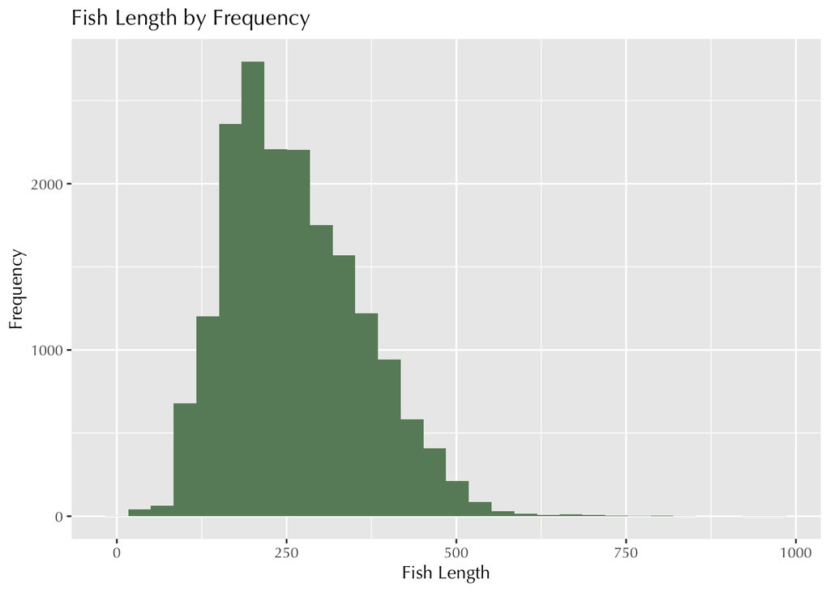

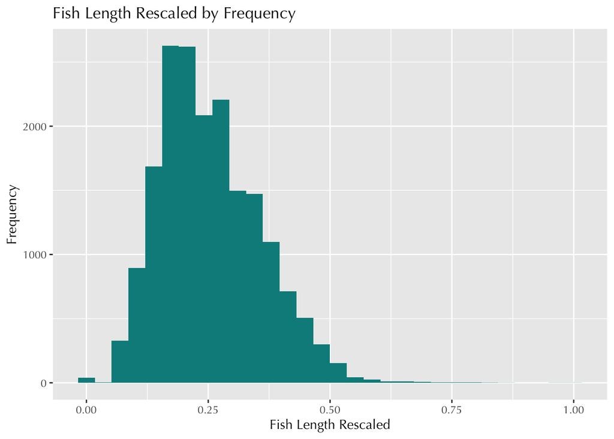

```r
ggplot(data = fish, mapping = aes(x = length)) +
  geom_histogram(fill = "darkseagreen4") +
  labs(y = "Frequency", x = "Fish Length", title = "Fish Length by Frequency") +
  theme(text = element_text(family = "Optima"))
ggplot(data = fish, mapping = aes(x = rescale_01(length))) +
  geom_histogram(fill = "cyan4") +
  labs(y = "Frequency", x = "Fish Length Rescaled", title = "Fish Length Rescaled by Frequency") +
  theme(text = element_text(family = "Optima"))
```

### 3.5 Incorporating Variables

```r
rescale_column <- function(data, column) {
  data <- data |>
    mutate(across(.col = {{ column }},
                  .fns = ~rescale_01(.x))
           )
  data
}
```

## 3.6 Another Function Test

```r
rescale_column(fish, c(length, weight))
```

```
# A tibble: 18,352 × 7
    trip  mark length  weight  year section  species
   <dbl> <dbl>  <dbl>   <dbl> <dbl> <chr>    <chr>
 1     1     0  0.280 0.0374   1989 Johnsrud RBT
 2     1     0  0.280 0.0406   1989 Johnsrud RBT
 3     1     0  0.277 0.0524   1989 Johnsrud RBT
 4     1     0  0.315 0.0588   1989 Johnsrud RBT
 5     1     0  0.305 0.0641   1989 Johnsrud RBT
 6     1     0  0.358 0.0812   1989 Johnsrud RBT
 7     1     0  0.261 0.0363   1989 Johnsrud RBT
 8     1     0  0.148 0.00855  1989 Johnsrud RBT
 9     1     0  0.203 0.0171   1989 Johnsrud RBT
10     1     0  0.145 0.00748  1989 Johnsrud RBT
# … with 18,342 more rows
```

## Revision

For Part 2 Question 2, I originally included two stopifnot functions inside of the function that I created. However, that is an example of inefficient code. To make it more efficient, I used a comma inside the function in order to apply both conditions inside the same function.

For Part 2 Question 1, I had used the {{}} operator to pull out var from the function. However, this is not necessary to do since you don’t need to use it for vector functions. So, to revise my code, I removed all areas in the function where it used {{}}.

For Part 2 Question 4, I rotated the orientation of the histogram as it was plotted on the opposite axis.